# Cyclistic bike-share study case

Iryan Peters

2024-11-07

This case study is part of the conclusion of the Google Data Analytics course. The methodology to be applied will be the Ask, Prepare, Process, Analyze, Share and Act (APPASA).

## Introduction

Cyclistic is a fictional bike-share company in Chicago that wants to increase annual memberships. To achieve this, me, as a junior data analyst, will analyze how casual riders and annual members use bikes differently. The analysis will guide a new marketing strategy to convert casual riders into annual members.

## Problem

How do annual members and casual riders use Cyclistic bikes differently?

## Solutions

Following the methodology APPASA, I present bellow the steps used to solve the problem.

### ASK

How do annual members and casual riders use Cyclistic bikes differently

### PREPARE

Loading all packages that helps to wrangle, visualize and clean data

```r
library("tidyverse")
```

```r
library("lubridate")
library("ggplot2")
library("dplyr")
library("tidyr")
```

**Where is the data located?**

The Cyclistic’s historical trip data is available to download in [this link](https://divvy-tripdata.s3.amazonaws.com/index.html). The data has been made available by Motivate International Inc. under [this license](https://divvy-tripdata.s3.amazonaws.com/index.html). This is public data that can be used to explore how different customer types are using Cyclistic bikes.

**How is the data organized?**

1. Read the files from Q1 2019 and Q2 2019 (there’s a limit of data usage in free plans)

```r
Divvy_Trips_2019_Q1 <- read_csv("Divvy_Trips_2019_Q1.csv")
Divvy_Trips_2019_Q2 <- read_csv("Divvy_Trips_2019_Q2.csv")
```

2. Check column names in each file to confirm the equality

```r
colnames(Divvy_Trips_2019_Q1)
```

```
##  [1] "trip_id"           "start_time"        "end_time"
##  [4] "bikeid"            "tripduration"      "from_station_id"
##  [7] "from_station_name" "to_station_id"     "to_station_name"
## [10] "usertype"          "gender"            "birthyear"
```

```r
colnames(Divvy_Trips_2019_Q2)
```

```
##  [1] "trip_id"           "start_time"        "end_time"
##  [4] "bikeid"            "tripduration"      "from_station_id"
##  [7] "from_station_name" "to_station_id"     "to_station_name"
## [10] "usertype"          "gender"            "birthyear"
```

3. Check the internal structure of the files

```r
str(Divvy_Trips_2019_Q1)
```

```
## spc_tbl_ [365,069 × 12] (S3: spec_tbl_df/tbl_df/tbl/data.frame)
##  $ trip_id          : num [1:365069] 21742443 21742444 21742445 21742446 21742447 ...
##  $ start_time       : POSIXct[1:365069], format: "2019-01-01 00:04:37" "2019-01-01 00:08:13" ...
##  $ end_time         : POSIXct[1:365069], format: "2019-01-01 00:11:07" "2019-01-01 00:15:34" ...
##  $ bikeid           : num [1:365069] 2167 4386 1524 252 1170 ...
##  $ tripduration     : num [1:365069] 390 441 829 1783 364 ...
##  $ from_station_id  : num [1:365069] 199 44 15 123 173 98 98 211 150 268 ...
##  $ from_station_name: chr [1:365069] "Wabash Ave & Grand Ave" "State St & Randolph St" "Racine Ave & 18th St" "California Ave & Milwaukee Ave" ...
##  $ to_station_id    : num [1:365069] 84 624 644 176 35 49 49 142 148 141 ...
##  $ to_station_name  : chr [1:365069] "Milwaukee Ave & Grand Ave" "Dearborn St & Van Buren St (*)" "Western Ave & Fillmore St (*)" "Clark St & Elm St" ...
##  $ usertype         : chr [1:365069] "Subscriber" "Subscriber" "Subscriber" "Subscriber" ...
##  $ gender           : chr [1:365069] "Male" "Female" "Female" "Male" ...
##  $ birthyear        : num [1:365069] 1989 1990 1994 1993 1994 ...
##  - attr(*, "spec")=
##   .. cols(
##   ..   trip_id = col_double(),
##   ..   start_time = col_datetime(format = ""),
##   ..   end_time = col_datetime(format = ""),
##   ..   bikeid = col_double(),
##   ..   tripduration = col_number(),
##   ..   from_station_id = col_double(),
##   ..   from_station_name = col_character(),
##   ..   to_station_id = col_double(),
##   ..   to_station_name = col_character(),
##   ..   usertype = col_character(),
##   ..   gender = col_character(),
##   ..   birthyear = col_double()
##   .. )
##  - attr(*, "problems")=<externalptr>
```

```r
str(Divvy_Trips_2019_Q2)
```

```
## spc_tbl_ [1,108,163 × 12] (S3: spec_tbl_df/tbl_df/tbl/data.frame)
##  $ trip_id          : num [1:1108163] 22178529 22178530 22178531 22178532 22178533 ...
##  $ start_time       : POSIXct[1:1108163], format: "2019-04-01 00:02:22" "2019-04-01 00:03:02" ...
##  $ end_time         : POSIXct[1:1108163], format: "2019-04-01 00:09:48" "2019-04-01 00:20:30" ...
##  $ bikeid           : num [1:1108163] 6251 6226 5649 4151 3270 ...
##  $ tripduration     : num [1:1108163] 446 1048 252 357 1007 ...
##  $ from_station_id  : num [1:1108163] 81 317 283 26 202 420 503 260 211 211 ...
##  $ from_station_name: chr [1:1108163] "Daley Center Plaza" "Wood St & Taylor St" "LaSalle St & Jackson Blvd" "McClurg Ct & Illinois St" ...
##  $ to_station_id    : num [1:1108163] 56 59 174 133 129 426 500 499 211 211 ...
##  $ to_station_name  : chr [1:1108163] "Desplaines St & Kinzie St" "Wabash Ave & Roosevelt Rd" "Canal St & Madison St" "Kingsbury St & Kinzie St" ...
##  $ usertype         : chr [1:1108163] "Subscriber" "Subscriber" "Subscriber" "Subscriber" ...
##  $ gender           : chr [1:1108163] "Male" "Female" "Male" "Male" ...
##  $ birthyear        : num [1:1108163] 1975 1984 1990 1993 1992 ...
##  - attr(*, "spec")=
##   .. cols(
##   ..   trip_id = col_double(),
##   ..   start_time = col_datetime(format = ""),
##   ..   end_time = col_datetime(format = ""),
##   ..   bikeid = col_double(),
##   ..   tripduration = col_number(),
##   ..   from_station_id = col_double(),
##   ..   from_station_name = col_character(),
##   ..   to_station_id = col_double(),
##   ..   to_station_name = col_character(),
##   ..   usertype = col_character(),
##   ..   gender = col_character(),
##   ..   birthyear = col_double()
##   .. )
##  - attr(*, "problems")=<externalptr>
```

```r
  Divvy_Trips_2019_Q1 <- mutate(Divvy_Trips_2019_Q1, tripduration = as.integer(tripduration))
  Divvy_Trips_2019_Q2 <- mutate(Divvy_Trips_2019_Q2, tripduration = as.integer(tripduration))
```

5. Combine all data in one dataset named *allrides*

```r
all_rides <- bind_rows(Divvy_Trips_2019_Q1, Divvy_Trips_2019_Q2)
```

### PROCESS

Process new dataset for data cleaning and prepared for analysis.

1. Check column names,

```r
colnames(all_rides)
```

```
##  [1] "trip_id"           "start_time"        "end_time"
##  [4] "bikeid"            "tripduration"      "from_station_id"
##  [7] "from_station_name" "to_station_id"     "to_station_name"
## [10] "usertype"          "gender"            "birthyear"
```

2. Check number of rows

```r
nrow(all_rides)
```

```
## [1] 1473232
```

3. Get a statistical summary of data

```r
summary(all_rides)
```

```
##     trip_id           start_time
##  Min.   :21742443   Min.   :2019-01-01 00:04:37.00
##  1st Qu.:22182589   1st Qu.:2019-04-01 14:18:06.75
##  Median :22616086   Median :2019-05-11 08:36:32.50
##  Mean   :22614520   Mean   :2019-04-30 03:51:33.00
##  3rd Qu.:23048272   3rd Qu.:2019-06-07 18:19:08.25
##  Max.   :23479387   Max.   :2019-06-30 23:59:05.00
##
##     end_time                          bikeid      tripduration
##  Min.   :2019-01-01 00:11:07.00   Min.   :   1   Min.   :      61
##  1st Qu.:2019-04-01 14:33:04.00   1st Qu.:1747   1st Qu.:     394
##  Median :2019-05-11 08:53:58.00   Median :3478   Median :     674
##  Mean   :2019-04-30 04:12:23.28   Mean   :3406   Mean   :    1250
##  3rd Qu.:2019-06-07 18:41:04.75   3rd Qu.:5095   3rd Qu.:    1222
##  Max.   :2019-07-06 14:22:25.00   Max.   :6471   Max.   :10628400
##
##  from_station_id from_station_name  to_station_id   to_station_name
##  Min.   :  1.0   Length:1473232     Min.   :  1.0   Length:1473232
##  1st Qu.: 77.0   Class :character   1st Qu.: 77.0   Class :character
##  Median :173.0   Mode  :character   Median :173.0   Mode  :character
##  Mean   :199.8                      Mean   :200.6
##  3rd Qu.:289.0                      3rd Qu.:289.0
##  Max.   :669.0                      Max.   :669.0
##
##    usertype            gender            birthyear
##  Length:1473232     Length:1473232     Min.   :1759
##  Class :character   Class :character   1st Qu.:1978
##  Mode  :character   Mode  :character   Median :1987
##                                        Mean   :1983
##                                        3rd Qu.:1991
##                                        Max.   :2014
##                                        NA's   :198976
```

4. Add new columns to list day of week

```r
all_rides$date <- as.Date(all_rides$start_time)
all_rides$day_of_week <- format(as.Date(all_rides$date), "%a")
view(all_rides)
```

5. Check if new column have been added

```r
colnames(all_rides)
```

```
##  [1] "trip_id"           "start_time"        "end_time"
##  [4] "bikeid"            "tripduration"      "from_station_id"
##  [7] "from_station_name" "to_station_id"     "to_station_name"
## [10] "usertype"          "gender"            "birthyear"
## [13] "date"              "day_of_week"
```

```r
all_rides_new <- all_rides[!(all_rides$tripduration <= 0 | all_rides$tripduration > 86440),]
all_rides_new <- all_rides_new[!duplicated(all_rides_new$trip_id),]
all_rides_new <- drop_na(all_rides_new)
dim(all_rides_new)
```

```
## [1] 1267630      14
```

```r
summary(all_rides_new)
```

```
##     trip_id           start_time
##  Min.   :21742443   Min.   :2019-01-01 00:04:37.00
##  1st Qu.:22141935   1st Qu.:2019-03-27 07:52:22.00
##  Median :22574807   Median :2019-05-07 20:52:05.00
##  Mean   :22583984   Mean   :2019-04-27 04:15:55.27
##  3rd Qu.:23020871   3rd Qu.:2019-06-06 15:13:29.25
##  Max.   :23479387   Max.   :2019-06-30 23:59:05.00
##     end_time                          bikeid      tripduration
##  Min.   :2019-01-01 00:11:07.00   Min.   :   1   Min.   :   61.0
##  1st Qu.:2019-03-27 08:03:00.00   1st Qu.:1754   1st Qu.:  365.0
##  Median :2019-05-07 21:03:36.00   Median :3491   Median :  601.0
##  Mean   :2019-04-27 04:30:17.77   Mean   :3418   Mean   :  862.5
##  3rd Qu.:2019-06-06 15:27:21.50   3rd Qu.:5113   3rd Qu.: 1016.0
##  Max.   :2019-07-01 07:41:49.00   Max.   :6471   Max.   :86385.0
##  from_station_id from_station_name  to_station_id   to_station_name
##  Min.   :  2.0   Length:1267630     Min.   :  2.0   Length:1267630
##  1st Qu.: 77.0   Class :character   1st Qu.: 80.0   Class :character
##  Median :174.0   Mode  :character   Median :174.0   Mode  :character
##  Mean   :202.9                      Mean   :203.5
##  3rd Qu.:289.0                      3rd Qu.:291.0
##  Max.   :664.0                      Max.   :664.0
##    usertype            gender            birthyear         date
##  Length:1267630     Length:1267630     Min.   :1759   Min.   :2019-01-01
##  Class :character   Class :character   1st Qu.:1978   1st Qu.:2019-03-27
##  Mode  :character   Mode  :character   Median :1987   Median :2019-05-07
##                                        Mean   :1983   Mean   :2019-04-26
##                                        3rd Qu.:1991   3rd Qu.:2019-06-06
##                                        Max.   :2014   Max.   :2019-06-30
##  day_of_week
##  Length:1267630
##  Class :character
##  Mode  :character
##
##
##
```

### Analyze

1. Calculate statistic indicators of length

```r
mean(all_rides_new$tripduration)
```

```
## [1] 862.4868
```

```r
median(all_rides_new$tripduration)
```

```
## [1] 601
```

```r
max(all_rides_new$tripduration)
```

```
## [1] 86385
```

```r
min(all_rides_new$tripduration)
```

```
## [1] 61
```

2. Calculate numbers of rides by day of week and usertype

```r
all_rides_new$day_of_week <-
    ordered(all_rides_new$day_of_week, levels = c('seg', 'ter', 'qua', 'qui', 'sex', 'sáb', 'dom'))
all_rides_new %>%
    group_by(usertype, day_of_week) %>%
    summarise(number_of_ride = n(), .groups = 'drop') %>%
    arrange(day_of_week)
```

```
## # A tibble: 14 × 3
##    usertype   day_of_week number_of_ride
##    <chr>      <ord>                <int>
##  1 Customer   seg                   9568
##  2 Subscriber seg                 176172
##  3 Customer   ter                   8636
##  4 Subscriber ter                 196488
##  5 Customer   qua                   8759
##  6 Subscriber qua                 201899
##  7 Customer   qui                   8665
##  8 Subscriber qui                 200532
##  9 Customer   sex                  12320
## 10 Subscriber sex                 193768
## 11 Customer   sáb                  20991
## 12 Subscriber sáb                 114350
## 13 Customer   dom                  16373
## 14 Subscriber dom                  99109
```

#### Findings:

- Non-subscribers customers are taking rides on weekends, most specially on Saturdays.
- The most popular day for subscribers is Wednesday.
3. Calculate the mean of rides length by day of week and usertype

```r
aggregate(all_rides_new$tripduration ~ all_rides_new$usertype + all_rides_new$day_of_week, FUN=mean)
```

```
##    all_rides_new$usertype all_rides_new$day_of_week all_rides_new$tripduration
## 1                Customer                       seg                  2187.2615
## 2              Subscriber                       seg                   744.2114
## 3                Customer                       ter                  2039.5390
## 4              Subscriber                       ter                   746.5307
## 5                Customer                       qua                  1982.8435
## 6              Subscriber                       qua                   751.2675
## 7                Customer                       qui                  2037.0010
## 8              Subscriber                       qui                   739.2680
## 9                Customer                       sex                  2127.0429
## 10             Subscriber                       sex                   738.2643
## 11               Customer                       sáb                  2387.6025
## 12             Subscriber                       sáb                   858.2596
## 13               Customer                       dom                  2401.7171
## 14             Subscriber                       dom                   859.5930
```

#### Findings:

- Non-subscribers (customers) rent their bikes for longer periods and longer distances than subscribers.
- This may indicate that non-subscribers use them for tourism and leisure, while subscribers use them for short routine activities.

### Share

1. Present the visualization of rides by day of week and user.

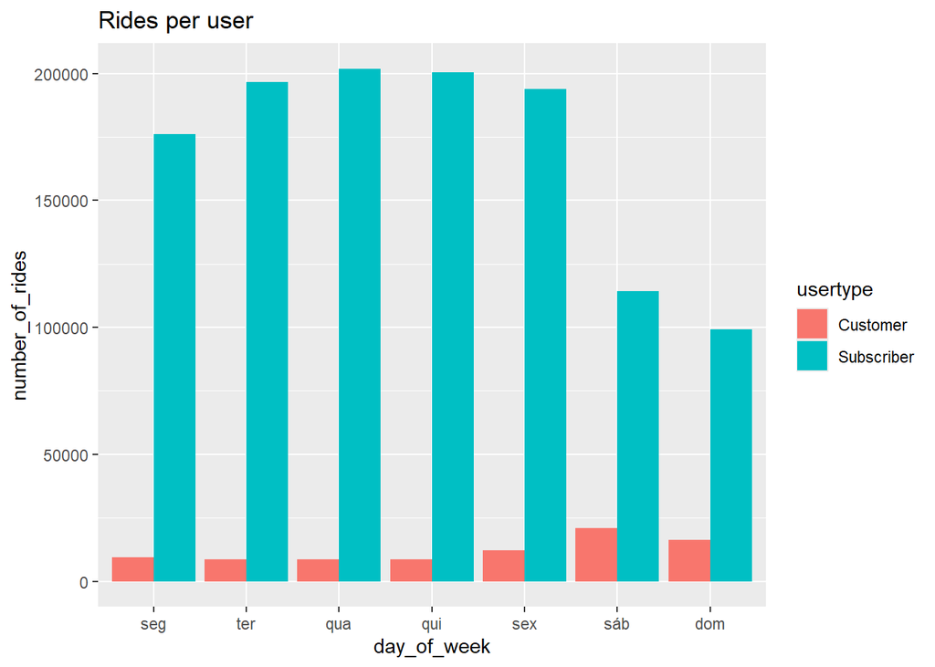

```r
all_rides_new %>%
    group_by(usertype, day_of_week) %>%
    summarise(number_of_rides = n(), .groups = 'drop') %>%
    ggplot(aes(x = day_of_week, y = number_of_rides, fill = usertype)) +
    geom_bar(position = "dodge", stat = "identity") +
    labs(title="Rides per user")
```

2. Present the visualization of rides length by day of week and usertype

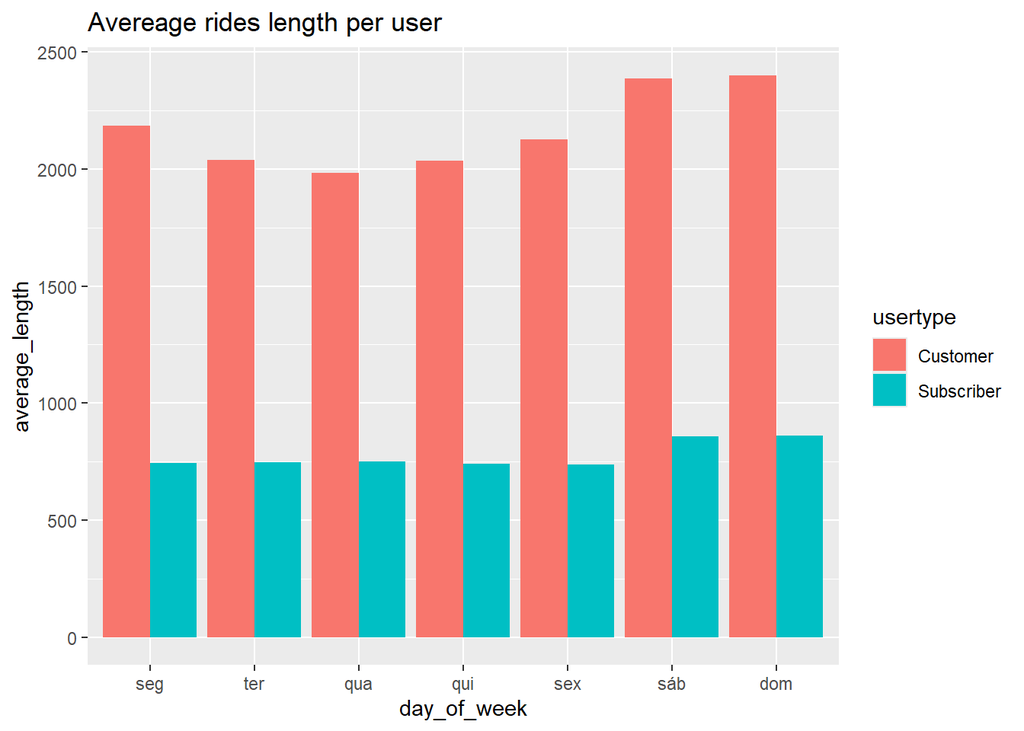

```r
all_rides_new %>%
    group_by(usertype, day_of_week) %>%
    summarise(average_length = mean(tripduration), .groups = 'drop') %>%
    ggplot(aes(x = day_of_week, y = average_length, fill = usertype)) +
    geom_bar(position = "dodge", stat = "identity") +
    labs(title="Avereage rides length per user")
```

### Conclusion

After analyzing the numbers, it was concluded that:

1. subscribers use the bikes more frequently on weekdays, for short periods and distances.
2. customers who rent the bikes use them more on Saturdays and Sundays and stay longer on each ride